# AfterWork Data Science: Data Visualisation with Python Project

## 1. Defining the Question

### a) Specifying the Data Analysis Question

Specify the reasearch question that you’ll be answering. i.e. Provide strategy recommendations that will lead to revenue growth.

### b) Defining the Metric for Success

The solutions to the following questions will help us answer our research question:

### e) Data Relevance

```r
library("tidyverse")
# loading data set.
# Checking the first and the last five records of the data set.
hilton_df <- read_csv("hotel_bookings.csv")
head(hilton_df)
```

```
## # A tibble: 6 × 32
##   hotel   is_ca…¹ lead_…² arriv…³ arriv…⁴ arriv…⁵ arriv…⁶ stays…⁷ stays…⁸ adults
##   <chr>     <dbl>   <dbl>   <dbl> <chr>     <dbl>   <dbl>   <dbl>   <dbl>  <dbl>
## 1 Resort…       0     342    2015 July         27       1       0       0      2
## 2 Resort…       0     737    2015 July         27       1       0       0      2
## 3 Resort…       0       7    2015 July         27       1       0       1      1
## 4 Resort…       0      13    2015 July         27       1       0       1      1
## 5 Resort…       0      14    2015 July         27       1       0       2      2
## 6 Resort…       0      14    2015 July         27       1       0       2      2
## # … with 22 more variables: children <dbl>, babies <dbl>, meal <chr>,
## #   country <chr>, market_segment <chr>, distribution_channel <chr>,
## #   is_repeated_guest <dbl>, previous_cancellations <dbl>,
## #   previous_bookings_not_canceled <dbl>, reserved_room_type <chr>,
## #   assigned_room_type <chr>, booking_changes <dbl>, deposit_type <chr>,
## #   agent <chr>, company <chr>, days_in_waiting_list <dbl>,
## #   customer_type <chr>, adr <dbl>, required_car_parking_spaces <dbl>, …
```

```r
tail(hilton_df)
```

```
## # A tibble: 6 × 32
##   hotel   is_ca…¹ lead_…² arriv…³ arriv…⁴ arriv…⁵ arriv…⁶ stays…⁷ stays…⁸ adults
##   <chr>     <dbl>   <dbl>   <dbl> <chr>     <dbl>   <dbl>   <dbl>   <dbl>  <dbl>
## 1 City H…       0       0    2017 August       33      15       0       1      2
## 2 City H…       0       0    2017 August       33      15       0       1      2
## 3 City H…       0     222    2017 August       32      11       2       3      2
## 4 City H…       0      89    2017 August       32      12       2       2      2
## 5 City H…       0     173    2017 August       32      10       2       4      2
## 6 City H…       0     170    2017 August       33      15       0       1      2
## # … with 22 more variables: children <dbl>, babies <dbl>, meal <chr>,
## #   country <chr>, market_segment <chr>, distribution_channel <chr>,
## #   is_repeated_guest <dbl>, previous_cancellations <dbl>,
## #   previous_bookings_not_canceled <dbl>, reserved_room_type <chr>,
## #   assigned_room_type <chr>, booking_changes <dbl>, deposit_type <chr>,
## #   agent <chr>, company <chr>, days_in_waiting_list <dbl>,
## #   customer_type <chr>, adr <dbl>, required_car_parking_spaces <dbl>, …
```

```r
sample(hilton_df,10)
```

```
## # A tibble: 118,200 × 10
##    adults previous_can…¹ booki…² stays…³ requi…⁴ reser…⁵ company stays…⁶ assig…⁷
##     <dbl>          <dbl>   <dbl>   <dbl>   <dbl> <chr>   <chr>     <dbl> <chr>
##  1      2              0       3       0       0 C       NULL          0 C
##  2      2              0       4       0       0 C       NULL          0 C
##  3      1              0       0       1       0 A       NULL          0 C
##  4      1              0       0       1       0 A       NULL          0 A
##  5      2              0       0       2       0 A       NULL          0 A
##  6      2              0       0       2       0 A       NULL          0 A
##  7      2              0       0       2       0 C       NULL          0 C
##  8      2              0       0       2       0 C       NULL          0 C
##  9      2              0       0       3       0 A       NULL          0 A
## 10      2              0       0       3       0 D       NULL          0 D
## # … with 118,190 more rows, 1 more variable: reservation_status <chr>, and
## #   abbreviated variable names ¹previous_cancellations, ²booking_changes,
## #   ³stays_in_week_nights, ⁴required_car_parking_spaces, ⁵reserved_room_type,
## #   ⁶stays_in_weekend_nights, ⁷assigned_room_type
```

```r
##  Checking number of rows and columns
dim(hilton_df)
```

```
## [1] 118200     32
```

```r
## Checking datatypes
str(hilton_df)
```

```
## spc_tbl_ [118,200 × 32] (S3: spec_tbl_df/tbl_df/tbl/data.frame)
##  $ hotel                         : chr [1:118200] "Resort Hotel" "Resort Hotel" "Resort Hotel" "Resort Hotel" ...
##  $ is_canceled                   : num [1:118200] 0 0 0 0 0 0 0 0 1 1 ...
##  $ lead_time                     : num [1:118200] 342 737 7 13 14 14 0 9 85 75 ...
##  $ arrival_date_year             : num [1:118200] 2015 2015 2015 2015 2015 ...
##  $ arrival_date_month            : chr [1:118200] "July" "July" "July" "July" ...
##  $ arrival_date_week_number      : num [1:118200] 27 27 27 27 27 27 27 27 27 27 ...
##  $ arrival_date_day_of_month     : num [1:118200] 1 1 1 1 1 1 1 1 1 1 ...
##  $ stays_in_weekend_nights       : num [1:118200] 0 0 0 0 0 0 0 0 0 0 ...
##  $ stays_in_week_nights          : num [1:118200] 0 0 1 1 2 2 2 2 3 3 ...
##  $ adults                        : num [1:118200] 2 2 1 1 2 2 2 2 2 2 ...
##  $ children                      : num [1:118200] 0 0 0 0 0 0 0 0 0 0 ...
##  $ babies                        : num [1:118200] 0 0 0 0 0 0 0 0 0 0 ...
##  $ meal                          : chr [1:118200] "BB" "BB" "BB" "BB" ...
##  $ country                       : chr [1:118200] "PRT" "PRT" "GBR" "GBR" ...
##  $ market_segment                : chr [1:118200] "Direct" "Direct" "Direct" "Corporate" ...
##  $ distribution_channel          : chr [1:118200] "Direct" "Direct" "Direct" "Corporate" ...
##  $ is_repeated_guest             : num [1:118200] 0 0 0 0 0 0 0 0 0 0 ...
##  $ previous_cancellations        : num [1:118200] 0 0 0 0 0 0 0 0 0 0 ...
##  $ previous_bookings_not_canceled: num [1:118200] 0 0 0 0 0 0 0 0 0 0 ...
##  $ reserved_room_type            : chr [1:118200] "C" "C" "A" "A" ...
##  $ assigned_room_type            : chr [1:118200] "C" "C" "C" "A" ...
##  $ booking_changes               : num [1:118200] 3 4 0 0 0 0 0 0 0 0 ...
##  $ deposit_type                  : chr [1:118200] "No Deposit" "No Deposit" "No Deposit" "No Deposit" ...
##  $ agent                         : chr [1:118200] "NULL" "NULL" "NULL" "304" ...
##  $ company                       : chr [1:118200] "NULL" "NULL" "NULL" "NULL" ...
##  $ days_in_waiting_list          : num [1:118200] 0 0 0 0 0 0 0 0 0 0 ...
##  $ customer_type                 : chr [1:118200] "Transient" "Transient" "Transient" "Transient" ...
##  $ adr                           : num [1:118200] 0 0 75 75 98 ...
##  $ required_car_parking_spaces   : num [1:118200] 0 0 0 0 0 0 0 0 0 0 ...
##  $ total_of_special_requests     : num [1:118200] 0 0 0 0 1 1 0 1 1 0 ...
##  $ reservation_status            : chr [1:118200] "Check-Out" "Check-Out" "Check-Out" "Check-Out" ...
##  $ reservation_status_date       : Date[1:118200], format: "2015-07-01" "2015-07-01" ...
##  - attr(*, "spec")=
##   .. cols(
##   ..   hotel = col_character(),
##   ..   is_canceled = col_double(),
##   ..   lead_time = col_double(),
##   ..   arrival_date_year = col_double(),
##   ..   arrival_date_month = col_character(),
```

[output cut: 14 more lines]

```
##   ..   reserved_room_type = col_character(),
##   ..   assigned_room_type = col_character(),
##   ..   booking_changes = col_double(),
##   ..   deposit_type = col_character(),
##   ..   agent = col_character(),
##   ..   company = col_character(),
##   ..   days_in_waiting_list = col_double(),
##   ..   customer_type = col_character(),
##   ..   adr = col_double(),
##   ..   required_car_parking_spaces = col_double(),
##   ..   total_of_special_requests = col_double(),
##   ..   reservation_status = col_character(),
##   ..   reservation_status_date = col_date(format = "")
##   .. )
##  - attr(*, "problems")=<externalptr>
```

Record your general observations below:

Observation 1: Most of the recods are numerical. Observation 2: There were columns with null values i.e agent and company.

## 3. External Data Source Validation

The data is originally from the article Hotel Booking Demand Datasets, by Nuno Antonio, Ana Almeida, and Luis Nunes for Data in Brief, Volume 22, February 2019.

```r
# checking missing data.
sum(is.na(hilton_df))
```

```
## [1] 4
```

```r
# Checking how many duplicate rows are there in the data
sum(duplicated(hilton_df))
```

```
## [1] 31793
```

```r
# Checking if any of the columns are all null
which(colSums(is.na(hilton_df))  == ncol(hilton_df))
```

```
## named integer(0)
```

We observe the following from our dataset:

Observation 1: There are no columns in which all the data is null

```r
# Checking if any of the rows are all null
which(rowSums(is.na(hilton_df)) == nrow(hilton_df))
```

```
## integer(0)
```

We observe the following from our dataset:

Observation 1: there is no row in which all the data is null

```r
# Checking the correlation of the features through the use of
# visualizations the correlation using heatmap

library(reshape2)
head(hilton_df)
```

```
## # A tibble: 6 × 32
##   hotel   is_ca…¹ lead_…² arriv…³ arriv…⁴ arriv…⁵ arriv…⁶ stays…⁷ stays…⁸ adults
##   <chr>     <dbl>   <dbl>   <dbl> <chr>     <dbl>   <dbl>   <dbl>   <dbl>  <dbl>
## 1 Resort…       0     342    2015 July         27       1       0       0      2
## 2 Resort…       0     737    2015 July         27       1       0       0      2
## 3 Resort…       0       7    2015 July         27       1       0       1      1
## 4 Resort…       0      13    2015 July         27       1       0       1      1
## 5 Resort…       0      14    2015 July         27       1       0       2      2
## 6 Resort…       0      14    2015 July         27       1       0       2      2
## # … with 22 more variables: children <dbl>, babies <dbl>, meal <chr>,
## #   country <chr>, market_segment <chr>, distribution_channel <chr>,
## #   is_repeated_guest <dbl>, previous_cancellations <dbl>,
## #   previous_bookings_not_canceled <dbl>, reserved_room_type <chr>,
## #   assigned_room_type <chr>, booking_changes <dbl>, deposit_type <chr>,
## #   agent <chr>, company <chr>, days_in_waiting_list <dbl>,
## #   customer_type <chr>, adr <dbl>, required_car_parking_spaces <dbl>, …
```

```r
# Select the desired columns
hilton_df2 <- hilton_df %>%
  na.omit() %>%
  select(is_canceled, stays_in_weekend_nights, stays_in_week_nights, adults, children, babies, is_repeated_guest, previous_cancellations, previous_bookings_not_canceled, days_in_waiting_list, total_of_special_requests)
hilton_df2
```

```
## # A tibble: 118,196 × 11
##    is_ca…¹ stays…² stays…³ adults child…⁴ babies is_re…⁵ previ…⁶ previ…⁷ days_…⁸
##      <dbl>   <dbl>   <dbl>  <dbl>   <dbl>  <dbl>   <dbl>   <dbl>   <dbl>   <dbl>
##  1       0       0       0      2       0      0       0       0       0       0
##  2       0       0       0      2       0      0       0       0       0       0
##  3       0       0       1      1       0      0       0       0       0       0
##  4       0       0       1      1       0      0       0       0       0       0
##  5       0       0       2      2       0      0       0       0       0       0
##  6       0       0       2      2       0      0       0       0       0       0
##  7       0       0       2      2       0      0       0       0       0       0
##  8       0       0       2      2       0      0       0       0       0       0
##  9       1       0       3      2       0      0       0       0       0       0
## 10       1       0       3      2       0      0       0       0       0       0
## # … with 118,186 more rows, 1 more variable: total_of_special_requests <dbl>,
## #   and abbreviated variable names ¹is_canceled, ²stays_in_weekend_nights,
## #   ³stays_in_week_nights, ⁴children, ⁵is_repeated_guest,
## #   ⁶previous_cancellations, ⁷previous_bookings_not_canceled,
## #   ⁸days_in_waiting_list
```

```r
# Create a correlation matrix
corr_matrix <- cor(hilton_df2, method="s")
head(corr_matrix)
```

```
##                           is_canceled stays_in_weekend_nights
## is_canceled              1.0000000000            -0.004177678
## stays_in_weekend_nights -0.0041776777             1.000000000
## stays_in_week_nights     0.0427650183             0.238550374
## adults                   0.0684490681             0.128235310
## children                -0.0008516207             0.053762237
## babies                  -0.0346423273             0.022674822
##                         stays_in_week_nights     adults      children
## is_canceled                       0.04276502 0.06844907 -0.0008516207
## stays_in_weekend_nights           0.23855037 0.12823531  0.0537622369
## stays_in_week_nights              1.00000000 0.15435050  0.0554466161
## adults                            0.15435050 1.00000000  0.0722175510
## children                          0.05544662 0.07221755  1.0000000000
## babies                            0.02693230 0.02781552  0.0391388400
##                              babies is_repeated_guest previous_cancellations
## is_canceled             -0.03464233      -0.086434696             0.26927022
## stays_in_weekend_nights  0.02267482      -0.097506835            -0.05526544
## stays_in_week_nights     0.02693230      -0.128836559            -0.06213865
## adults                   0.02781552      -0.178019101            -0.03597821
## children                 0.03913884      -0.034779099            -0.05858906
## babies                   1.00000000      -0.009484828            -0.01739429
##                         previous_bookings_not_canceled days_in_waiting_list
## is_canceled                                -0.11701377           0.09716263
## stays_in_weekend_nights                    -0.08410795          -0.07511541
## stays_in_week_nights                       -0.11940819           0.01208728
## adults                                     -0.21099031          -0.03657861
## children                                   -0.03504757          -0.04807593
## babies                                     -0.01117328          -0.01419862
##                         total_of_special_requests
## is_canceled                           -0.25727649
## stays_in_weekend_nights                0.08116941
## stays_in_week_nights                   0.07657209
## adults                                 0.16008984
## children                               0.09502877
## babies                                 0.09356335
```

```r
# Create a table with long form
corr_df <- melt(corr_matrix)
corr_df
```

```
##                               Var1                           Var2         value
## 1                      is_canceled                    is_canceled  1.0000000000
## 2          stays_in_weekend_nights                    is_canceled -0.0041776777
## 3             stays_in_week_nights                    is_canceled  0.0427650183
## 4                           adults                    is_canceled  0.0684490681
## 5                         children                    is_canceled -0.0008516207
## 6                           babies                    is_canceled -0.0346423273
## 7                is_repeated_guest                    is_canceled -0.0864346957
## 8           previous_cancellations                    is_canceled  0.2692702159
## 9   previous_bookings_not_canceled                    is_canceled -0.1170137659
## 10            days_in_waiting_list                    is_canceled  0.0971626299
## 11       total_of_special_requests                    is_canceled -0.2572764915
## 12                     is_canceled        stays_in_weekend_nights -0.0041776777
## 13         stays_in_weekend_nights        stays_in_weekend_nights  1.0000000000
## 14            stays_in_week_nights        stays_in_weekend_nights  0.2385503741
```

[output cut: 107 more lines]

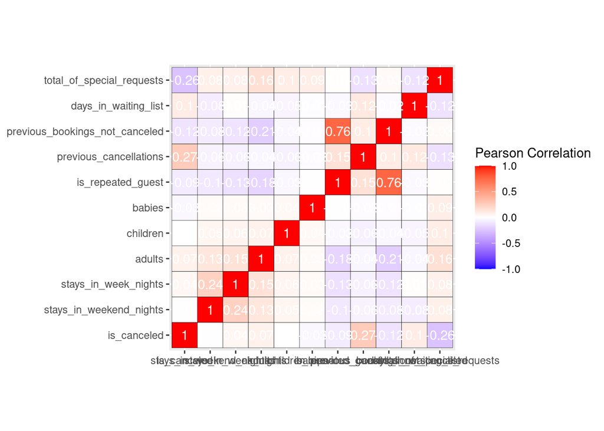

```r
# Plot the heatmap
ggplot(corr_df, aes(Var1, Var2, fill = value)) +
  geom_tile(color = "black") +
  geom_text(
    aes(label = round(value, 2)),
    color = "white"
  ) +
  coord_fixed() +
  labs(
    fill="Pearson Correlation"
  ) +
  scale_fill_gradient2(
    low = "blue",
    high = "red",
    mid = "white",
    limit = c(-1,1)
  ) +
  theme(
    axis.title.x = element_blank(),
    axis.title.y = element_blank()
  )
```

```r
# Dropping company column because it has alot of missing values
# and we won't need to answer any of our questions
hilton_df = select(hilton_df, -company)
head(hilton_df)
```

```
## # A tibble: 6 × 31
##   hotel   is_ca…¹ lead_…² arriv…³ arriv…⁴ arriv…⁵ arriv…⁶ stays…⁷ stays…⁸ adults
##   <chr>     <dbl>   <dbl>   <dbl> <chr>     <dbl>   <dbl>   <dbl>   <dbl>  <dbl>
## 1 Resort…       0     342    2015 July         27       1       0       0      2
## 2 Resort…       0     737    2015 July         27       1       0       0      2
## 3 Resort…       0       7    2015 July         27       1       0       1      1
## 4 Resort…       0      13    2015 July         27       1       0       1      1
## 5 Resort…       0      14    2015 July         27       1       0       2      2
## 6 Resort…       0      14    2015 July         27       1       0       2      2
## # … with 21 more variables: children <dbl>, babies <dbl>, meal <chr>,
## #   country <chr>, market_segment <chr>, distribution_channel <chr>,
## #   is_repeated_guest <dbl>, previous_cancellations <dbl>,
## #   previous_bookings_not_canceled <dbl>, reserved_room_type <chr>,
## #   assigned_room_type <chr>, booking_changes <dbl>, deposit_type <chr>,
## #   agent <chr>, days_in_waiting_list <dbl>, customer_type <chr>, adr <dbl>,
## #   required_car_parking_spaces <dbl>, total_of_special_requests <dbl>, …
```

```r
# We replace the mising values i.e. for TO
hilton_df$agent[is.na(hilton_df$agent)] <- "TO"
hilton_df
```

```
## # A tibble: 118,200 × 31
##    hotel  is_ca…¹ lead_…² arriv…³ arriv…⁴ arriv…⁵ arriv…⁶ stays…⁷ stays…⁸ adults
##    <chr>    <dbl>   <dbl>   <dbl> <chr>     <dbl>   <dbl>   <dbl>   <dbl>  <dbl>
##  1 Resor…       0     342    2015 July         27       1       0       0      2
##  2 Resor…       0     737    2015 July         27       1       0       0      2
##  3 Resor…       0       7    2015 July         27       1       0       1      1
##  4 Resor…       0      13    2015 July         27       1       0       1      1
##  5 Resor…       0      14    2015 July         27       1       0       2      2
##  6 Resor…       0      14    2015 July         27       1       0       2      2
##  7 Resor…       0       0    2015 July         27       1       0       2      2
##  8 Resor…       0       9    2015 July         27       1       0       2      2
##  9 Resor…       1      85    2015 July         27       1       0       3      2
## 10 Resor…       1      75    2015 July         27       1       0       3      2
## # … with 118,190 more rows, 21 more variables: children <dbl>, babies <dbl>,
## #   meal <chr>, country <chr>, market_segment <chr>,
## #   distribution_channel <chr>, is_repeated_guest <dbl>,
## #   previous_cancellations <dbl>, previous_bookings_not_canceled <dbl>,
## #   reserved_room_type <chr>, assigned_room_type <chr>, booking_changes <dbl>,
## #   deposit_type <chr>, agent <chr>, days_in_waiting_list <dbl>,
## #   customer_type <chr>, adr <dbl>, required_car_parking_spaces <dbl>, …
```

```r
# We drop rows where there is no adult, baby and child as
# these records won't help us.

hilton_df <- subset(hilton_df, adults!=0 | children!=0 | babies!=0)
hilton_df
```

```
## # A tibble: 118,020 × 31
##    hotel  is_ca…¹ lead_…² arriv…³ arriv…⁴ arriv…⁵ arriv…⁶ stays…⁷ stays…⁸ adults
##    <chr>    <dbl>   <dbl>   <dbl> <chr>     <dbl>   <dbl>   <dbl>   <dbl>  <dbl>
##  1 Resor…       0     342    2015 July         27       1       0       0      2
##  2 Resor…       0     737    2015 July         27       1       0       0      2
##  3 Resor…       0       7    2015 July         27       1       0       1      1
##  4 Resor…       0      13    2015 July         27       1       0       1      1
##  5 Resor…       0      14    2015 July         27       1       0       2      2
##  6 Resor…       0      14    2015 July         27       1       0       2      2
##  7 Resor…       0       0    2015 July         27       1       0       2      2
##  8 Resor…       0       9    2015 July         27       1       0       2      2
##  9 Resor…       1      85    2015 July         27       1       0       3      2
## 10 Resor…       1      75    2015 July         27       1       0       3      2
## # … with 118,010 more rows, 21 more variables: children <dbl>, babies <dbl>,
## #   meal <chr>, country <chr>, market_segment <chr>,
## #   distribution_channel <chr>, is_repeated_guest <dbl>,
## #   previous_cancellations <dbl>, previous_bookings_not_canceled <dbl>,
## #   reserved_room_type <chr>, assigned_room_type <chr>, booking_changes <dbl>,
## #   deposit_type <chr>, agent <chr>, days_in_waiting_list <dbl>,
## #   customer_type <chr>, adr <dbl>, required_car_parking_spaces <dbl>, …
```

```r
# We replace missing children values with rounded mean value
# ---
# Hint i.e. use round()
hilton_df$children[is.na(hilton_df$children)] <- round(mean(hilton_df$children, na.rm = TRUE), 0)
hilton_df
```

```
## # A tibble: 118,020 × 31
##    hotel  is_ca…¹ lead_…² arriv…³ arriv…⁴ arriv…⁵ arriv…⁶ stays…⁷ stays…⁸ adults
##    <chr>    <dbl>   <dbl>   <dbl> <chr>     <dbl>   <dbl>   <dbl>   <dbl>  <dbl>
##  1 Resor…       0     342    2015 July         27       1       0       0      2
##  2 Resor…       0     737    2015 July         27       1       0       0      2
##  3 Resor…       0       7    2015 July         27       1       0       1      1
##  4 Resor…       0      13    2015 July         27       1       0       1      1
##  5 Resor…       0      14    2015 July         27       1       0       2      2
##  6 Resor…       0      14    2015 July         27       1       0       2      2
##  7 Resor…       0       0    2015 July         27       1       0       2      2
##  8 Resor…       0       9    2015 July         27       1       0       2      2
##  9 Resor…       1      85    2015 July         27       1       0       3      2
## 10 Resor…       1      75    2015 July         27       1       0       3      2
## # … with 118,010 more rows, 21 more variables: children <dbl>, babies <dbl>,
## #   meal <chr>, country <chr>, market_segment <chr>,
## #   distribution_channel <chr>, is_repeated_guest <dbl>,
## #   previous_cancellations <dbl>, previous_bookings_not_canceled <dbl>,
## #   reserved_room_type <chr>, assigned_room_type <chr>, booking_changes <dbl>,
## #   deposit_type <chr>, agent <chr>, days_in_waiting_list <dbl>,
## #   customer_type <chr>, adr <dbl>, required_car_parking_spaces <dbl>, …
```

```r
# Checking for missing values in the dataframe
sum(is.na(hilton_df))
```

```
## [1] 0
```

```r
# Converting the datatypes of the following columns from float to integer
# i.e. children, company, agent
as.integer(hilton_df$children)
```

[output not shown]

[output cut: 4153 more lines]

```r
hilton_df
```

```
## # A tibble: 118,020 × 31
##    hotel  is_ca…¹ lead_…² arriv…³ arriv…⁴ arriv…⁵ arriv…⁶ stays…⁷ stays…⁸ adults
##    <chr>    <dbl>   <dbl>   <dbl> <chr>     <dbl>   <dbl>   <dbl>   <dbl>  <dbl>
##  1 Resor…       0     342    2015 July         27       1       0       0      2
##  2 Resor…       0     737    2015 July         27       1       0       0      2
##  3 Resor…       0       7    2015 July         27       1       0       1      1
##  4 Resor…       0      13    2015 July         27       1       0       1      1
##  5 Resor…       0      14    2015 July         27       1       0       2      2
##  6 Resor…       0      14    2015 July         27       1       0       2      2
##  7 Resor…       0       0    2015 July         27       1       0       2      2
##  8 Resor…       0       9    2015 July         27       1       0       2      2
##  9 Resor…       1      85    2015 July         27       1       0       3      2
## 10 Resor…       1      75    2015 July         27       1       0       3      2
## # … with 118,010 more rows, 21 more variables: children <dbl>, babies <dbl>,
## #   meal <chr>, country <chr>, market_segment <chr>,
## #   distribution_channel <chr>, is_repeated_guest <dbl>,
## #   previous_cancellations <dbl>, previous_bookings_not_canceled <dbl>,
## #   reserved_room_type <chr>, assigned_room_type <chr>, booking_changes <dbl>,
## #   deposit_type <chr>, agent <chr>, days_in_waiting_list <dbl>,
## #   customer_type <chr>, adr <dbl>, required_car_parking_spaces <dbl>, …
```

```r
## 5. Solution Implementation
### 5.a) Questions

# 1. How many bookings were cancelled?
# ---
# Visualisation: Barplot

hilton_df %>%
  group_by(reservation_status) %>%
  summarise(is_canceled = sum(is_canceled))
```

```
## # A tibble: 3 × 2
##   reservation_status is_canceled
##   <chr>                    <dbl>
## 1 Canceled                 42993
## 2 Check-Out                    0
## 3 No-Show                   1206
```

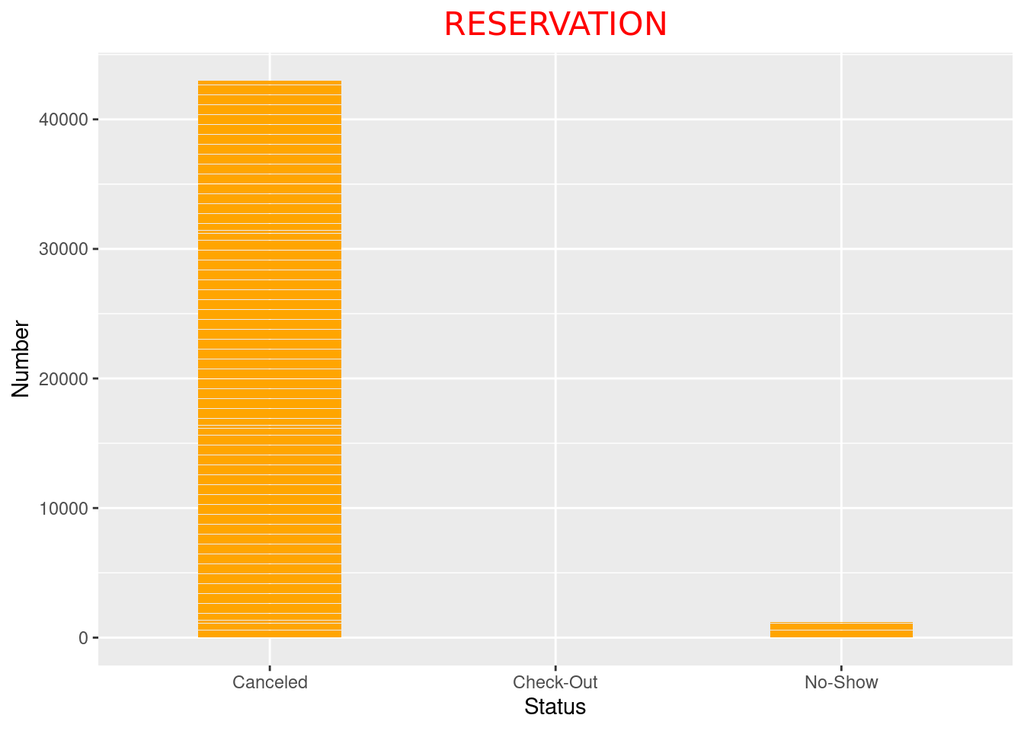

```r
ggplot(hilton_df, aes(x= reservation_status, y= is_canceled))+
  geom_col(stat = "identity", width =  0.5, fill= "orange") +
  labs(
    title = "RESERVATION",
    x= "Status",
    y= "Number"
  ) +
  theme(
    plot.title = element_text(hjust = 0.5, size=16, family="Ariel Black", color="red")
  )
```

```r
# 2. What was the booking ratio between resort hotel and city hotel?
# Barplot of booking ratio between resort hotel and city hotel

city_df <- hilton_df %>%
  count(hotel)
city_df
```

```
## # A tibble: 2 × 2
##   hotel            n
##   <chr>        <int>
## 1 City Hotel   77973
## 2 Resort Hotel 40047
```

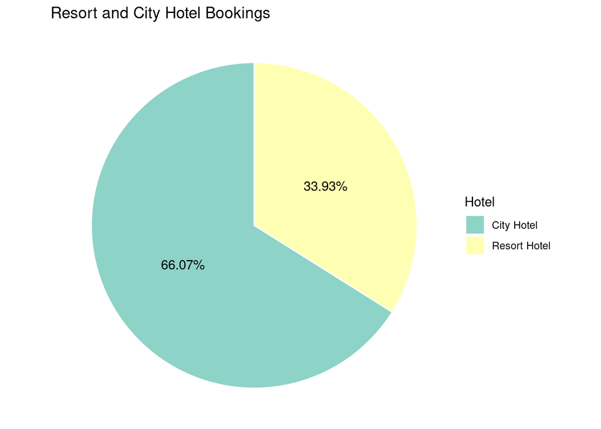

```r
ggplot(data=city_df, aes(x="", y=n, fill=hotel)) +
  geom_bar(
    stat="identity", width=0.5, color = "white"
  ) +
  coord_polar("y") +
  geom_text(
    aes(label = paste0(round(n / sum(n) * 100, 2), "%")), position = position_stack(vjust = 0.5)) +
  scale_fill_brewer(palette="Set3")+
  labs(
    fill = "Hotel",
    title = "Resort and City Hotel Bookings"
  )+
  theme_void()
```

```r
# 3. What was the percentage of booking for each year?

per_yearly_bookings <- hilton_df %>%
  count(arrival_date_year)
per_yearly_bookings
```

```
## # A tibble: 3 × 2
##   arrival_date_year     n
##               <dbl> <int>
## 1              2015 21967
## 2              2016 56623
## 3              2017 39430
```

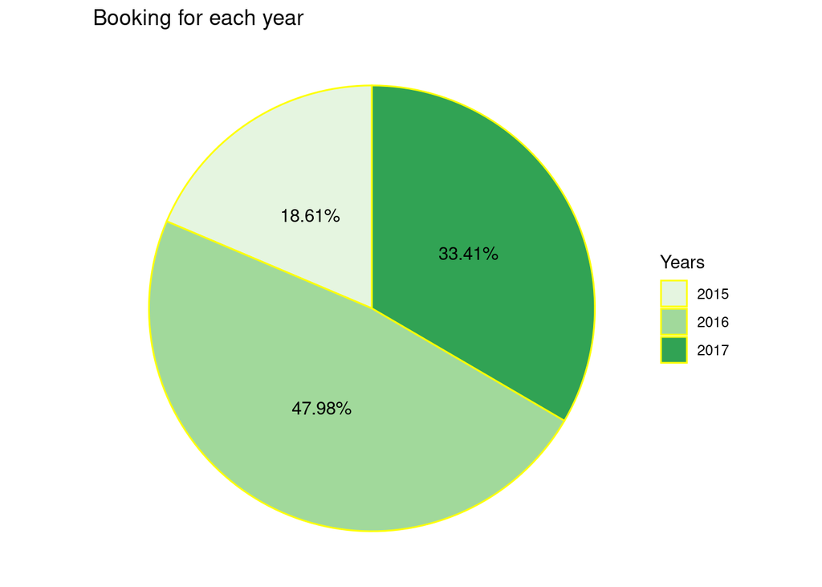

```r
ggplot(data=per_yearly_bookings, aes(x="", y=n, fill=factor(arrival_date_year))) +
  geom_bar(
    stat="identity", width=0.5, color = "yellow"
  ) +
  coord_polar("y") +
    geom_text(
    aes(label = paste0(round(n / sum(n) * 100, 2), "%")), position = position_stack(vjust = 0.5)
  ) +
  scale_fill_brewer(palette="Set4") +
  labs(
    fill = "Years",
    title = "Booking for each year") +
  theme_void()
```

```r
# 4. Which were the most busiest months for hotels?
high_booking_months <- hilton_df %>%
  count(arrival_date_month)
high_booking_months
```

```
## # A tibble: 12 × 2
##    arrival_date_month     n
##    <chr>              <int>
##  1 April              11078
##  2 August             12671
##  3 December            6759
##  4 February            8052
##  5 January             5921
##  6 July               12644
##  7 June               10929
##  8 March               9768
##  9 May                11780
## 10 November            6771
## 11 October            11147
## 12 September          10500
```

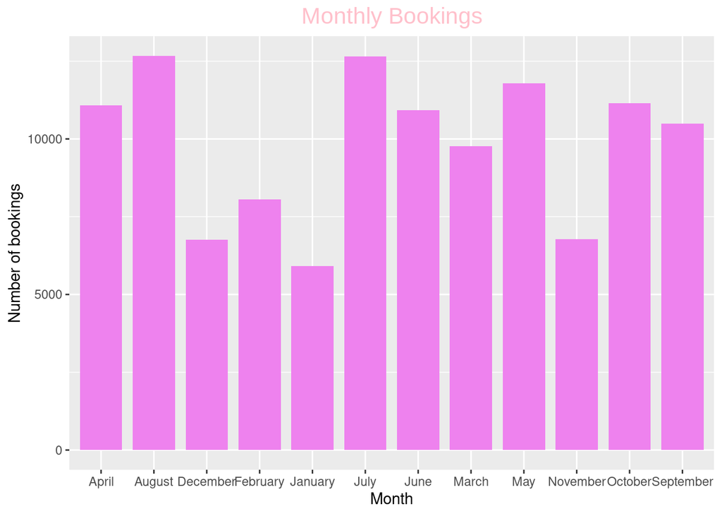

```r
ggplot(high_booking_months, aes(x= arrival_date_month, y= n))+
  geom_col(stat = "identity", width =  0.8, fill= "violet") +
  labs(
    title = "Monthly Bookings",
    x= "Month",
    y= "Number of bookings"
  ) +
  theme(
    plot.title = element_text(hjust = 0.5, size=16, family="Arial", color="pink")
  )
```

```r
# 5. From which top 3 countries did most guests come from?
hilton_df
```

```
## # A tibble: 118,020 × 31
##    hotel  is_ca…¹ lead_…² arriv…³ arriv…⁴ arriv…⁵ arriv…⁶ stays…⁷ stays…⁸ adults
##    <chr>    <dbl>   <dbl>   <dbl> <chr>     <dbl>   <dbl>   <dbl>   <dbl>  <dbl>
##  1 Resor…       0     342    2015 July         27       1       0       0      2
##  2 Resor…       0     737    2015 July         27       1       0       0      2
##  3 Resor…       0       7    2015 July         27       1       0       1      1
##  4 Resor…       0      13    2015 July         27       1       0       1      1
##  5 Resor…       0      14    2015 July         27       1       0       2      2
##  6 Resor…       0      14    2015 July         27       1       0       2      2
##  7 Resor…       0       0    2015 July         27       1       0       2      2
##  8 Resor…       0       9    2015 July         27       1       0       2      2
##  9 Resor…       1      85    2015 July         27       1       0       3      2
## 10 Resor…       1      75    2015 July         27       1       0       3      2
## # … with 118,010 more rows, 21 more variables: children <dbl>, babies <dbl>,
## #   meal <chr>, country <chr>, market_segment <chr>,
## #   distribution_channel <chr>, is_repeated_guest <dbl>,
## #   previous_cancellations <dbl>, previous_bookings_not_canceled <dbl>,
## #   reserved_room_type <chr>, assigned_room_type <chr>, booking_changes <dbl>,
## #   deposit_type <chr>, agent <chr>, days_in_waiting_list <dbl>,
## #   customer_type <chr>, adr <dbl>, required_car_parking_spaces <dbl>, …
```

```r
countries <- hilton_df %>%
  group_by(country) %>%
  summarise(guests = sum(adults)+sum(children)+sum(babies)) %>%
  # arrange(desc(guests)) %>%
  top_n(3)
countries
```

```
## # A tibble: 3 × 2
##   country guests
##   <chr>    <dbl>
## 1 FRA      21244
## 2 GBR      24247
## 3 PRT      89723
```